# course5hw1

Jimmy Nunnally

November 16, 2020

library(ggplot2)

Code for reading in the dataset and/or processing the data Histogram of the total number of steps taken each day Mean and median number of steps taken each day Time series plot of the average number of steps taken The 5-minute interval that, on average, contains the maximum number of steps Code to describe and show a strategy for imputing missing data Histogram of the total number of steps taken each day after missing values are imputed Panel plot comparing the average number of steps taken per 5-minute interval across weekdays and weekends All of the R code needed to reproduce the results (numbers, plots, etc.) in the report

```r
file <- "course5hw1.zip"
site <- "https://d396qusza40orc.cloudfront.net/repdata%2Fdata%2Factivity.zip"
download.file(site, file,method="curl")
unzip(file)
```

# 1 Load the dataset

```r
A <- read.csv("activity.csv", stringsAsFactors=FALSE)

#1 Transform the date attribute to an actual date format
A$date <- as.POSIXct(A$date, format="%Y-%m-%d")

#1 Compute the weekdays from the date attribute
A <- data.frame(date=A$date,
                           weekday=tolower(weekdays(A$date)),
                           steps=A$steps,
                           interval=A$interval)

#1 Compute whether weekend or weekday
A <- cbind(A,
                      daytype=ifelse(A$weekday == "saturday" |
                                     A$weekday == "sunday", "weekend",
                                     "weekday"))

#1 Make the final date frame
activity <- data.frame(date=A$date,
                       weekday=A$weekday,
                       daytype=A$daytype,
                       interval=A$interval,
                       steps=A$steps)
```

```r
head(activity)
```

```
##         date weekday daytype interval steps
## 1 2012-10-01  monday weekday        0    NA
## 2 2012-10-01  monday weekday        5    NA
## 3 2012-10-01  monday weekday       10    NA
## 4 2012-10-01  monday weekday       15    NA
## 5 2012-10-01  monday weekday       20    NA
## 6 2012-10-01  monday weekday       25    NA
```

# 2 Histogram

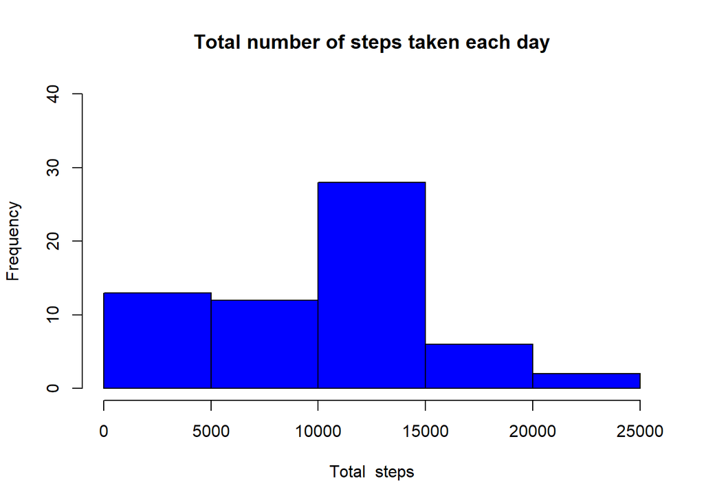

```r
sum_data <- aggregate(activity$steps, by=list(activity$date), FUN=sum, na.rm=TRUE)
names(sum_data) <- c("date", "total")
hist(sum_data$total,
     breaks=seq(from=0, to=25000, by=5000),
     col="blue",
     xlab="Total  steps",
     ylim=c(0, 40),
     main="Total number of steps taken each day")
```

# 3 Mean and median total steps per day

```r
mean(sum_data$total)
```

```
## [1] 9354.23
```

```r
median(sum_data$total)
```

```
## [1] 10395
```

# 4 Compute the means of steps accross all days for each interval

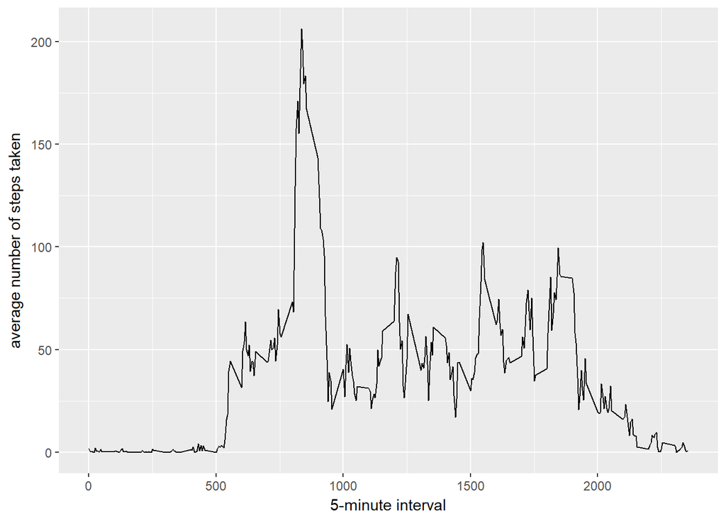

```r
library(ggplot2)
mean_data <- aggregate(activity$steps,
                       by=list(activity$interval),
                       FUN=mean,
                       na.rm=TRUE)

names(mean_data) <- c("interval", "mean")
 ggplot(data=mean_data, aes(interval,mean)) +
   geom_line() +     xlab("5-minute interval") +     ylab("average number of steps taken")
```

# 5 The 5-minute interval that, on average, contains the maximum number of steps

```r
max_interval <- which.max(mean_data$mean)
mean_data[max_interval, ]
```

```
##     interval     mean
## 104      835 206.1698
```

# 6 Code to describe and show a strategy for imputing missing data

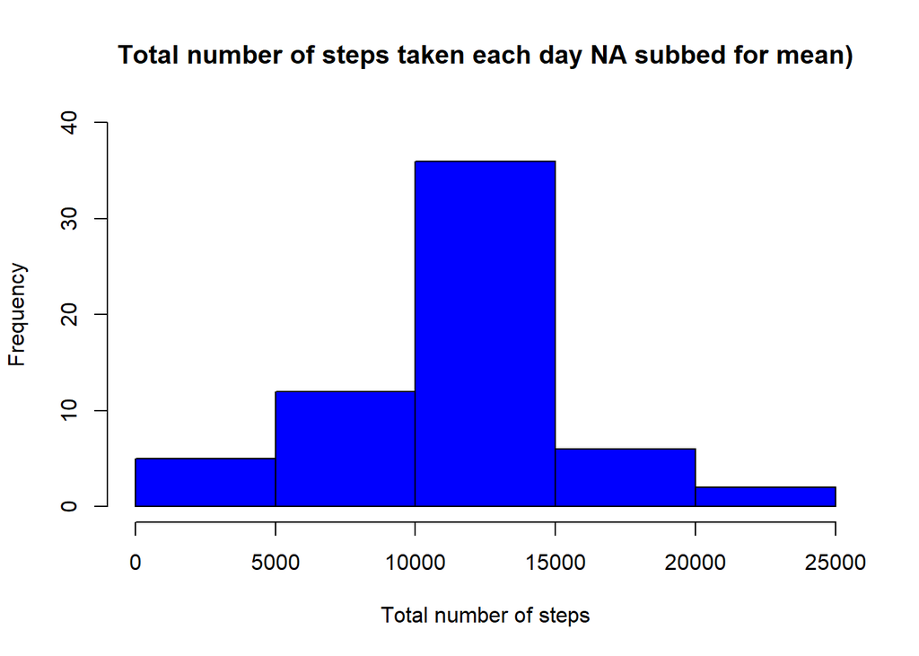

```r
# Find the NA positions
na_pos <- which(is.na(activity$steps))

# Create a vector of means
mean_vec <- rep(mean(activity$steps, na.rm=TRUE), times=length(na_pos))
#Create a new dataset that is equal to the original dataset but with the missing data filled in.
# Replace the NAs by the means
activity[na_pos, "steps"] <- mean_vec

# Compute the total number of steps each day (NA values removed)
sum_data <- aggregate(activity$steps, by=list(activity$date), FUN=sum)

# Rename the attributes
names(sum_data) <- c("date", "total")

#Total number of steps with means  subbed in for missing value
hist(sum_data$total,
     breaks=seq(from=0, to=25000, by=5000),
     col="blue",
     xlab="Total number of steps",
     ylim=c(0, 40),
     main="Total number of steps taken each day NA subbed for mean)")
```

# 7 Panel plot comparing the average number of steps taken per 5-minute interval across weekdays and weekends

```r
library(ggplot2)
mean(sum_data$total)
```

```
## [1] 10766.19
```

```r
median(sum_data$total)
```

```
## [1] 10766.19
```

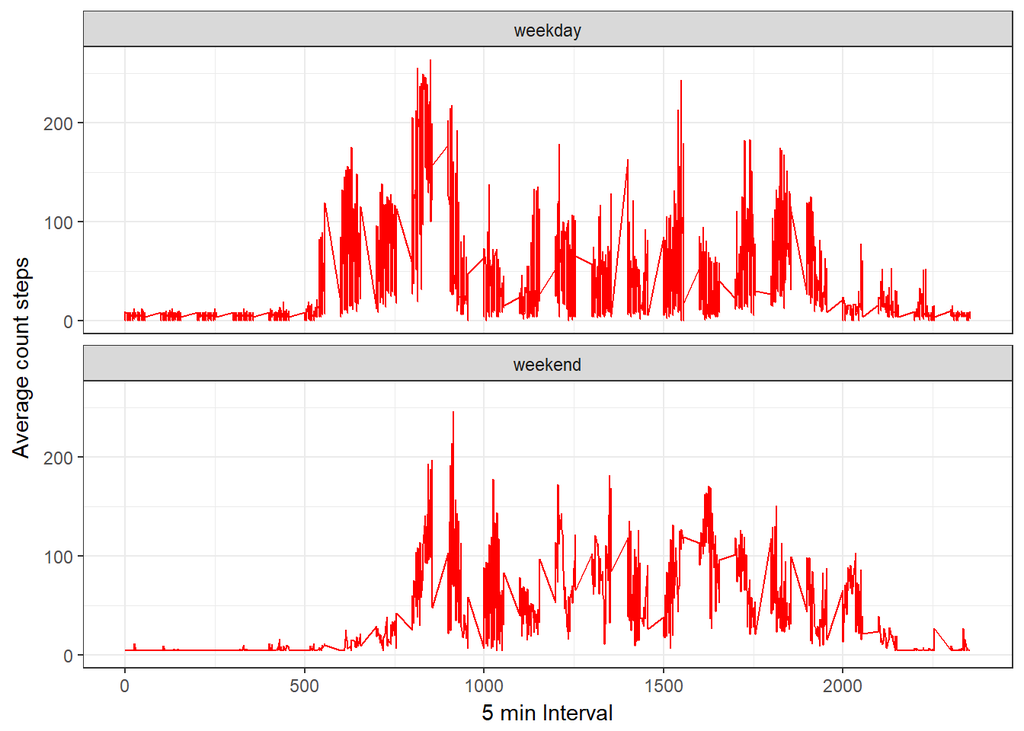

```r
# Compute the average number of steps taken\averaged across all variables
mean_data <- aggregate(activity$steps,
                       by=list(activity$daytype,
                               activity$weekday, activity$interval), mean)
names(mean_data) <- c("daytype", "weekday", "interval", "mean")

ggplot(mean_data,aes(interval,mean))+
         geom_line(color="red") +
        facet_wrap(~ daytype, nrow=2, ncol=1) +
        labs(x="5 min Interval", y="Average count steps") +
        theme_bw()
```